# Understanding CUDA Memory Usage

Created On: Aug 23, 2023 | Last Updated On: Jul 07, 2026

To debug CUDA memory use, PyTorch provides a way to generate memory snapshots that record the state of allocated CUDA memory at any point in time, and optionally record the history of allocation events that led up to that snapshot.

The generated snapshots can then be drag and dropped onto the interactiver viewer hosted at pytorch.org/memory_viz which can be used to explore the snapshot.

Note

By default, the memory profiler only has visibility into CUDA device memory allocated and managed through the PyTorch allocator (e.g., `torch.empty(..., device='cuda')`, :func:`torch.cuda.memory.CUDAPluggableAllocator`). CPU pinned memory (host memory) can optionally be included by passing `record_pinned_host_memory=True` to :func:`~torch.cuda.memory._record_memory_history`; see Including Pinned (Host) Memory below.

Any memory allocated directly from CUDA APIs in C++ (e.g., `cudaMalloc`, `cuMemCreate`) or via third-party Python bindings such as `cuda-python <https://github.com/NVIDIA/cuda-python>`_ will not be visible in the PyTorch memory profiler. NCCL (used for distributed communication on CUDA devices) is a common example of a library that allocates GPU memory outside of PyTorch’s allocator. See Identifying Non-PyTorch allocations for more info.

## Generating a Snapshot

The common pattern for recording a snapshot is to enable memory history, run the code to be observed, and then save a file with a pickled snapshot:

```
# enable memory history, which will
# add tracebacks and event history to snapshots
torch.cuda.memory._record_memory_history()

run_your_code()
torch.cuda.memory._dump_snapshot("my_snapshot.pickle")
```

## Using the visualizer

Open https://pytorch.org/memory_viz and drag/drop the pickled snapshot file into the visualizer. The visualizer is a javascript application that runs locally on your computer. It does not upload any snapshot data.

## Including Pinned (Host) Memory

By default, memory snapshots only include CUDA device memory. To also capture CPU pinned memory allocations (e.g., tensors created with `pin_memory=True`), pass `record_pinned_host_memory=True`:

```
torch.cuda.memory._record_memory_history(record_pinned_host_memory=True)

run_your_code()
snapshot = torch.cuda.memory._snapshot()
# Host allocator data is in snapshot["host_segments"] and snapshot["host_traces"]
torch.cuda.memory._dump_snapshot("my_snapshot.pickle")
```

To record only host pinned memory and skip the CUDA device allocator entirely, pair `record_pinned_host_memory=True` with `record_cuda=False`:

```
torch.cuda.memory._record_memory_history(record_pinned_host_memory=True, record_cuda=False)
```

Note

The pytorch.org/memory_viz visualizer does not yet support displaying host memory data. You can inspect `host_segments` and `host_traces` programmatically from the snapshot dict.

## Active Memory Timeline

The Active Memory Timeline shows all the live tensors over time in the snapshot on a particular GPU. Pan/Zoom over the plot to look at smaller allocations. Mouse over allocated blocks to see a stack trace for when that block was allocated, and details like its address. The detail slider can be adjusted to render fewer allocations and improve performance when there is a lot of data.

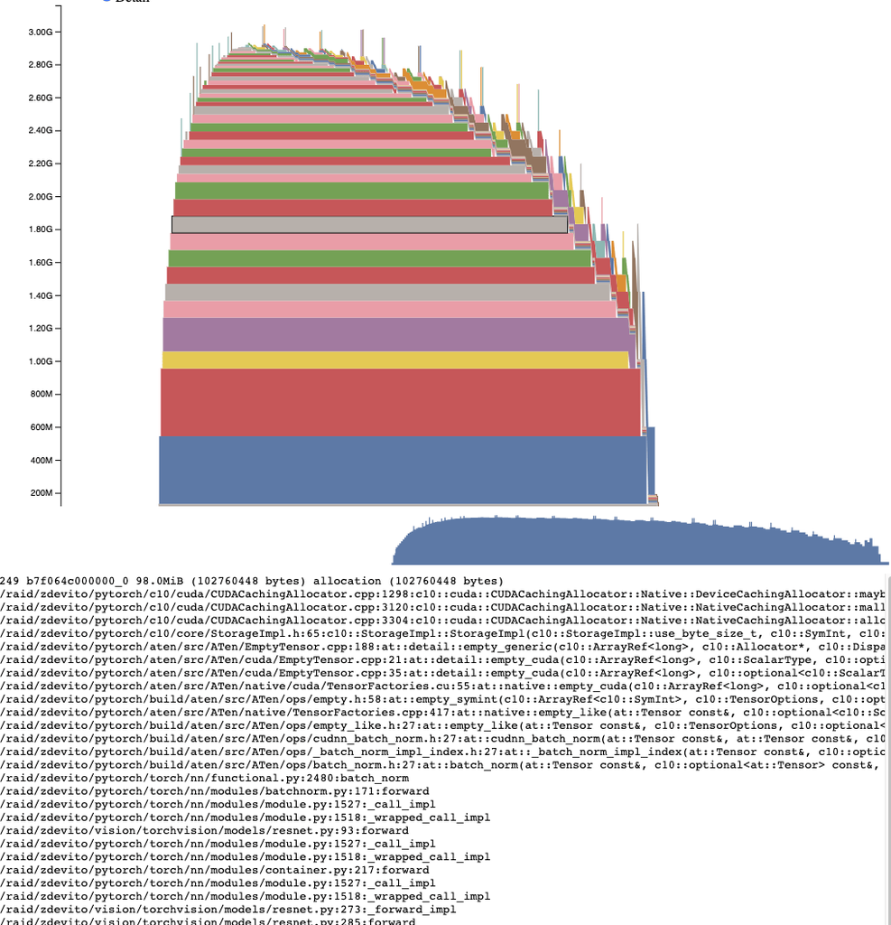

## Allocator State History

The Allocator State History shows individual allocator events in a timeline on the left. Select an event in the timeline to see a visual summary of the allocator state at that event. This summary shows each individual segment returned from cudaMalloc and how it is split up into blocks of individual allocations or free space. Mouse over segments and blocks to see the stack trace when the memory was allocated. Mouse over events to see the stack trace when the event occurred, such as when a tensor was freed. Out of memory errors are reported as OOM events. Looking at the state of memory during an OOM may provide insight into why an allocation failed even though reserved memory still exists.

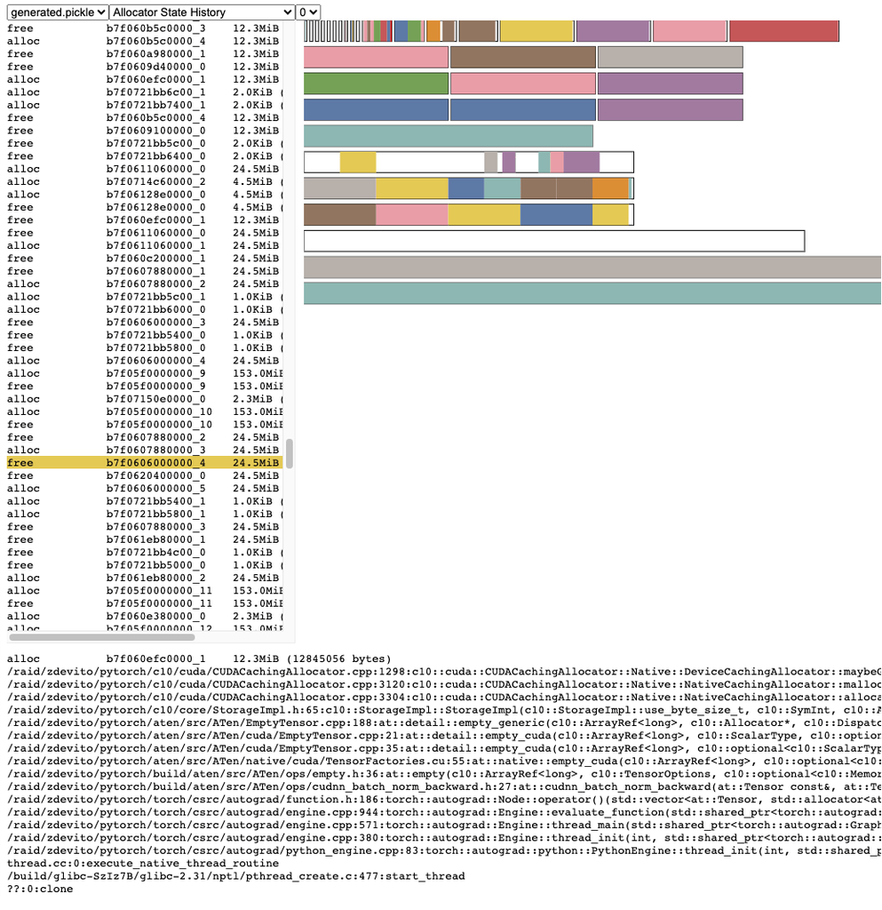

The stack trace information also reports the address at which an allocation occurred. The address b7f064c000000_0 refers to the (b)lock at address 7f064c000000 which is the “_0”th time this address was allocated. This unique string can be looked up in the Active Memory Timeline and searched in the Active State History to examine the memory state when a tensor was allocated or freed.

## Identifying Non-PyTorch allocations

If you suspect CUDA memory is being allocated outside of PyTorch, you can collect the raw CUDA allocation info using the pynvml package, and compare that to the allocation reported by pytorch.

To collect raw memory usage outside pytorch, use `device_memory_used()`

```
import torch
device_idx = ...
print(torch.cuda.device_memory_used(device_idx))
```

## Snapshot API Reference

**`torch.cuda.memory._record_memory_history(enabled='all', context='all', stacks='all', max_entries=9223372036854775807, device=None, clear_history=False, compile_context=False, global_record_annotations=False, skip_actions=None, record_pinned_host_memory=False, record_cuda=True)` [[source]](https://github.com/pytorch/pytorch/blob/v2.14.0/torch/cuda/memory.py#L897)**

Enable recording of stack traces associated with memory allocations, so you can tell what allocated any piece of memory in `torch.cuda.memory._snapshot()`.

In addition to keeping stack traces with each current allocation and free, this will also enable recording of a history of all alloc/free events.

Use `torch.cuda.memory._snapshot()` to retrieve this information, and the tools in `_memory_viz.py` to visualize snapshots.

### Buffer behavior

This will store up to `max_entries` instances of `TraceEntry` when enabled. Python trace collection defaults to `sys.maxsize`, meaning long-running or indefinitely running jobs should set a reasonable limit to avoid excessive memory use. Expect each entry to be several KB.

Longer running workflows or those with smaller `max_entries` values will only store the last accumulated `max_entries` entries, meaning new entries overwrite older entries.

C++ implementation for reference to ring buffer implementation:

```
if (record_history) {
  if (alloc_trace->size() < alloc_trace_max_entries_) {
    alloc_trace->emplace_back(te);
  } else {
    (*alloc_trace)[alloc_trace_next++] = te;
    if (alloc_trace_next == alloc_trace_max_entries_) {
      alloc_trace_next = 0;
    }
  }
}
```

### Latency impact

The Python trace collection is fast (2us per trace), so you may consider enabling this on production jobs if you anticipate ever having to debug memory issues.

C++ trace collection is also fast (~50ns/frame), which for many typical programs works out to ~2us per trace, but can vary depending on stack depth.

**param enabled:**

`None`, disable recording memory history. `“state”`, keep information for currently allocated memory. `“all”`, additionally keep a history of all alloc/free calls. Defaults to “all”.

**type enabled:**

Literal[None, “state”, “all”], optional

**param context:**

`None`, Do not record any tracebacks. `“state”`, Record tracebacks for currently allocated memory. `“alloc”`, additionally keep tracebacks for alloc calls. `“all”`, additionally keep tracebacks for free calls. Defaults to “all”.

**type context:**

Literal[None, “state”, “alloc”, “all”], optional

**param stacks:**

`“python”`, include Python, TorchScript, and inductor frames in tracebacks `“all”`, additionally include C++ frames Defaults to “all”.

**type stacks:**

Literal[“python”, “all”], optional

**param max_entries:**

Keep a maximum of `max_entries` alloc/free events in the recorded history recorded.

**type max_entries:**

int, optional

**param clear_history:**

Clear history when enabling, defaults to False.

**type clear_history:**

bool, optional

**param skip_actions:**

List of action types to skip when recording memory history. This can be used to reduce memory overhead by excluding certain types of events from being recorded. Valid action types are:

- `“alloc”`: Memory allocation events
- `“free_requested”`: Free requests (memory marked for freeing)
- `“free_completed”`: Completed free operations (memory actually freed)
- `“segment_alloc”`: Segment allocation from cudaMalloc
- `“segment_free”`: Segment freed back to CUDA via cudaFree
- `“oom”`: Out-of-memory exceptions
- `“snapshot”`: Memory snapshot generation events

For example, to skip recording free_requested events: `skip_actions=[“free_requested”]`

Defaults to None (record all actions).

**type skip_actions:**

list[str], optional

**param record_pinned_host_memory:**

If True, also record memory history for the CPU pinned memory (host) allocator. Host allocator traces will appear in the `host_segments` and `host_traces` keys of the snapshot returned by `_snapshot()`. Defaults to False.

**type record_pinned_host_memory:**

bool, optional

**param record_cuda:**

If True, record memory history for the CUDA device allocator. Set to False (together with `record_pinned_host_memory=True`) to record only host pinned memory. Defaults to True.

**type record_cuda:**

bool, optional

**`torch.cuda.memory._snapshot(device=None, augment_with_fx_traces=False)` [[source]](https://github.com/pytorch/pytorch/blob/v2.14.0/torch/cuda/memory.py#L1044)**

Save a snapshot of CUDA memory state at the time it was called.

The state is represented as a dictionary with the following structure.

```
class Snapshot(TypedDict):
    segments: List[Segment]
    device_traces: List[List[TraceEntry]]


class Segment(TypedDict):
    # Segments are memory returned from a cudaMalloc call.
    # The size of reserved memory is the sum of all Segments.
    # Segments are cached and reused for future allocations.
    # If the reuse is smaller than the segment, the segment
    # is split into more than one Block.
    # empty_cache() frees Segments that are entirely inactive.
    address: int
    total_size: int  #  cudaMalloc'd size of segment
    stream: int
    segment_type: Literal["small", "large"]  # 'large' (>1MB)
    segment_pool_id: Tuple[
        int, int
    ]  # id of the memory pool owning this segment
    allocated_size: int  # size of memory in use
    active_size: int  # size of memory in use or in active_awaiting_free state
    blocks: List[Block]


class Block(TypedDict):
    # A piece of memory returned from the allocator, or
    # current cached but inactive.
    size: int
    requested_size: int  # size requested during malloc, may be smaller than
    # size due to rounding
    address: int
    state: Literal[
        "active_allocated",  # used by a tensor
        "active_awaiting_free",  # waiting for another stream to finish using
        # this, then it will become free
        "inactive",
    ]  # free for reuse
    frames: List[Frame]  # stack trace from where the allocation occurred


class Frame(TypedDict):
    filename: str
    line: int
    name: str
    # Optional FX debug fields (present when augment_with_fx_traces=True
    # and the frame corresponds to FX-generated code)
    fx_node_op: str  # FX node operation type (e.g., 'call_function', 'output')
    fx_node_name: str  # FX node name (e.g., 'linear', 'relu_1')
    fx_original_trace: str  # Original model source code stack trace


class TraceEntry(TypedDict):
    # When `torch.cuda.memory._record_memory_history()` is enabled,
    # the snapshot will contain TraceEntry objects that record each
    # action the allocator took.
    action: Literal[
        "alloc"  # memory allocated
        "free_requested",  # the allocated received a call to free memory
        "free_completed",  # the memory that was requested to be freed is now
        # able to be used in future allocation calls
        "segment_alloc",  # the caching allocator ask cudaMalloc for more memory
        # and added it as a segment in its cache
        "segment_free",  # the caching allocator called cudaFree to return memory
        # to cuda possibly trying free up memory to
        # allocate more segments or because empty_caches was called
        "oom",  # the allocator threw an OOM exception. 'size' is
        # the requested number of bytes that did not succeed
        "snapshot",  # the allocator generated a memory snapshot
        # useful to correlate a previously taken
        # snapshot with this trace
        "annotate",  # metadata was attached to a live allocation
        # via _annotate_tensor. 'addr' is the allocation's base
        # address and 'user_metadata' holds the annotation
    ]
    addr: int  # not present for OOM
    frames: List[Frame]
    size: int
    stream: int
    device_free: int  # only present for OOM, the amount of
    # memory cuda still reports to be free
    pool_id: Tuple[int, int]  # id of the memory pool for this entry
```

**Returns:**

The Snapshot dictionary object

**`torch.cuda.memory._dump_snapshot(filename='dump_snapshot.pickle', augment_with_fx_traces=False)` [[source]](https://github.com/pytorch/pytorch/blob/v2.14.0/torch/cuda/memory.py#L1149)**

Save a pickled version of the `torch.memory._snapshot()` dictionary to a file.

This file can be opened by the interactive snapshot viewer at pytorch.org/memory_viz

Snapshot file sizes scale with `max_entries` and stack trace depth per entry, with several KB per entry. These can easily be in the GB range for longer running workflows with large `max_entries`.

**Parameters:**

- **filename** (str*,* *optional*) – Name of the file to create. Defaults to “dump_snapshot.pickle”.
- **augment_with_fx_traces** (bool*,* *optional*) – If True, augment the snapshot with FX debug information before dumping. This maps generated FX code stack traces back to original model source code. Defaults to False.